# Análise de dados longitudinais (Parte 2): O pacote lavaan para equações estruturais

Tiago Ferreira

Abril, 2021

AGENDA | O pacote lavaan para equações estruturais:  
**1. Especificação de modelos**  
**2. Estimação de modelos**  
**3. Extração de resultados**  
**4. Modelos de pistas**

### O pacote lavaan para modelação de equações estruturais no R

- Software de distribuição livre, não comercial;
- Desenvolvido por Yves Rosseel, Department of Data Analysis, Ghent University;
- **Suporta para um extenso número de procedimentos utilizados em SEM:**
  - Análise Fatorial Confirmatória - CFA();
  - Modelação de Equações Estruturais - SEM();
  - Modelação geral de estruturas de médias e covariâncias - lavaan();
  - Permite modelar variáveis contínuas, dicotómicas ou ordinais.

### Instalação e documentação de apoio

```r
install.packages("lavaan")
library(lavaan)
help(package="lavaan")
website do lavaan: browseURL("http://lavaan.org")
```

- **Existem 3 tipos de comandos na utilização geral do lavaan:**
  - Comandos para especificação de modelos;
  - Comandos para estimação de modelos;
  - Comandos para extração de resultados.

# 1. Especificação de modelos

## Fórmula do modelo

- Código que permite descrever o modelo a avaliar.
- **O lavaan utiliza a sintaxe base do R para especificar fórmulas de regressão (ver parte 1):**
  - Exemplo: y ~ x + z
- Um modelo no lavaan é constituido por um sistema de fórmulas de equações entre aspas.

```r
meu_model <- "y ~ x + m
              m ~ x"
```

- **Cada linha de um modelo é uma fórmula com 3 partes:**
  - “left-hand side” (lhs);
  - “operator” (op);
  - “right-hand side” (rhs).

*Exemplo:* **y (lhs) ~ (op) x1 + x2 + x3 (rhs)**

*Nota: uso de + no rhs equivale a:*  
“y ~ x1  
y ~ x2  
y ~ x3”

### Operadores

| Tipo | Operador | Exemplo |
| --- | --- | --- |
| variável latente | =~ | x =~ x1 + x2 (x é medido por x1 e x2 |
| regressão | ~ | y ~ x (regressão de y em x) |
| (co)variância | ~~ | x ~~ y (correlação entre x e y) |
| intercept | ~1 | x~1 (representa o intercept de x) |
| escala | * | x =~ 1 * x1 + 1 * x2 (usado para fixar parâmetros) |
| definir par. | := | y ~ c * x + b * m; m ~ a * x; ind := a * c (usado para especificar parâmetros) |
| igualar par. | == | x =~ a * x1 + b * x2; a==b (usado para impor igualdade entre parâmetros |

### Modificadores

- Elementos à direita do “~” podem ser precedidos de modificadores.
- Os modificadores servem geralmente para libertar ou fixar parâmetros.

```r
meu_modelo <- "
          # Variáveis latentes
          x =~ NA*x1 + x2 + x3
          y =~ NA*y1 + y2 + y3
          z =~ NA*z1 + z2 + z3
          # correlações entre fatores
          x ~~ 1*x
          y ~~ 1*y
          z ~~ 1*z
          "
```

- Podem também ser utilizados para impor condições

```r
meu_modelo <- "
          x =~ L1.1*x1 + L1.2*x2 + L1.3*x3
          y =~ L2.1*y1 + L2.2*y2 + L2.3*y3
          z =~ L3.1*z1 + L3.2*z2 + L3.3*z3
          # Condições
          L1.1 == L2.1
          L1.2 == L2.2
          L1.3 == L2.3
          L3.1 == (L3.2 + L3.3)^2
          "
```

# 2. Estimação de modelos

## A função **lavaan()**

- **A função base para ajustar um modelo é **lavaan()**:**
  - Esta função não tem qualquer opção selecionada por defeito;
  - Por isso, é necessário que o utilizador identifique o modelo.

```r
library(lavaan)
```

```r
args("lavaan")
```

```
## function (model = NULL, data = NULL, ordered = NULL, sampling.weights = NULL,
##     sample.cov = NULL, sample.mean = NULL, sample.th = NULL,
##     sample.nobs = NULL, group = NULL, cluster = NULL, constraints = "",
##     WLS.V = NULL, NACOV = NULL, slotOptions = NULL, slotParTable = NULL,
##     slotSampleStats = NULL, slotData = NULL, slotModel = NULL,
##     slotCache = NULL, sloth1 = NULL, ...)
## NULL
```

- Vários argumentos da função **lavaan()** podem ser utilizados para automaticamente fixar parâmetros e identificar os modelos.

```r
meu_modelo <- "
          # Variáveis latentes
          x =~ L1.1*x1 + L1.2*x2 + L1.3*x3
          y =~ L2.1*y1 + L2.2*y2 + L2.3*y3
          z =~ L3.1*z1 + L3.2*z2 + L3.3*z3
          # Correlações entre fatores
          x ~~ y + z
          y ~~ z
          "
fit <- lavaan(meu_modelo, data = meus_dados, # nome do modelo e dados
              auto.fix.first = TRUE,  # fixa a 1.0 o primeiro loading de cada latente
              auto.var = TRUE) # estima variâncias e variâncias residuais
```

```r
?lavOptions # ver a lista de argumentos
```

## As funções **cfa()** e **sem()**

- O lavaan inclui duas funções alternativas, **cfa()** e **sem()** para ajustar modelos - funções segunda ordem muito semelhantes entre si.
- **cfa() e sem() definem um conjunto de opções por defeito, nomeadamente:**
  - **auto.var = TRUE** (estima variâncias);
  - **auto.cov.lv.x = TRUE** (estima covariâncias entre variáveis exógenas);
  - **auto.fix.first = TRUE** (fixa primeiro loading a 1.0).

```r
?cfa
?sem
?lavOptions
lavOptions()
```

```r
head(lavOptions())
```

```
## $model.type
## [1] "sem"
##
## $mimic
## [1] "lavaan"
##
## $meanstructure
## [1] "default"
##
## $int.ov.free
## [1] FALSE
##
## $int.lv.free
## [1] FALSE
##
## $conditional.x
## [1] "default"
```

# 3. Extração de resultados

- Existem várias funções que permitem extrair diferentes tipos de resultados.
- **Algumas das mais utilizadas são;**
  - **summary(fit)** (apresenta sumário dos resultados);
  - **lavInspect(fit)** (apresenta uma lista das matrizes dos modelos e dos parâmetros livres e estimados);
  - **predict(fit)** (calcula os scores fatoriais);
  - **parameterEstimates(fit)** (apresenta as estimativas dos parâmetros);
  - **fitMeasures(fit)** (apresenta medidas de ajustamento);
  - **modindice(fit)** (apresenta índices de modificação).
- Alguns argumentos podem completar os resultados base da função **summary()**.

```r
meu_modelo <- "
          # Variáveis latentes
          x =~ L1.1*x1 + L1.2*x2 + L1.3*x3
          y =~ L2.1*y1 + L2.2*y2 + L2.3*y3
          # Correlações entre fatores
          x ~~ y
          "
fit <- lavaan(meu_modelo, data = meus_dados, # nome do modelo e dados
              auto.fix.first = TRUE,  # fixa a 1.0 o primeiro loading de cada latente
              auto.var = TRUE) # estima variâncias e variâncias residuais

summary(fit, standardized=TRUE, rsq=TRUE, fit.measures=TRUE, modindices=TRUE)
# sumário mais completo
```

# 4. Modelos de regressão e modelos de pistas

## Configurações iniciais

### Preparação de pacotes

- Para reproduzir os seguintes exemplos será necessário carregar 3 pacotes:

```r
library(lavaan)
library(semTools)
library(semPlot)
```

### Importação de dados

- **Iremos utilizar uma base de dados construída a partir dos dados descritivos de:**
  - Roth, D. L., Wiebe, D. J., Fillingim, R. B., & Shay, K. A. (1989). Life events, fitness, hardiness, and health: A simultaneous analysis of proposed stress-resistance effects. Journal of Personality and Social Psychology, 57(1), 136–142. https://doi.org/10.1037/0022-3514.57.1.136

- Podemos importar esta base de dados para o R através do seguinte código:

```r
DF_roth <-
  read.csv(
    "G:\\My Drive\\FPCEUP\\R trainning\\GitRepo\\Intro to Lavaan\\Intro to Lavaa_DATA\\DF_roth.csv")
```

- Esta base de dados é utilizada por Rex Kline no seu conhecido livro dedicado à modelação de equações estruturais

[figure not shown]

## Alguma estatística descritiva

### Características gerais da base de dados

```r
dim(DF_roth)
```

```
## [1] 373   5
```

```r
names(DF_roth)
```

```
## [1] "exercise" "hardy"    "fitness"  "stress"   "illness"
```

```r
head(DF_roth,4)
```

```
##    exercise     hardy   fitness     stress  illness
## 1  97.58960 -0.243680  84.47890 -35.537440 796.8197
## 2  66.65038  2.783052  99.26339 -49.774773 625.6883
## 3 162.71042 44.812489  77.80067  -2.816133 735.6340
## 4  86.11467 15.079458 130.17116  78.125718 774.0359
```

### Sumário

```r
summary(DF_roth)
```

```
##     exercise            hardy             fitness           stress
##  Min.   :-131.705   Min.   :-131.062   Min.   :-46.47   Min.   :-188.720
##  1st Qu.:  -6.544   1st Qu.: -24.194   1st Qu.: 42.28   1st Qu.: -41.003
##  Median :  44.308   Median :   2.154   Median : 68.18   Median :   4.749
##  Mean   :  40.900   Mean   :   0.000   Mean   : 67.10   Mean   :   4.800
##  3rd Qu.:  81.163   3rd Qu.:  22.470   3rd Qu.: 90.05   3rd Qu.:  51.436
##  Max.   : 257.746   Max.   : 160.870   Max.   :174.68   Max.   : 195.264
##     illness
##  Min.   :554.8
##  1st Qu.:674.2
##  Median :718.6
##  Mean   :716.7
##  3rd Qu.:759.7
##  Max.   :922.4
```

### Correlações

```r
cor(DF_roth)
```

```
##          exercise hardy fitness stress illness
## exercise     1.00 -0.03    0.39  -0.05   -0.08
## hardy       -0.03  1.00    0.07  -0.23   -0.16
## fitness      0.39  0.07    1.00  -0.13   -0.29
## stress      -0.05 -0.23   -0.13   1.00    0.34
## illness     -0.08 -0.16   -0.29   0.34    1.00
```

## Regressão linear simples: efeito da prática de exercício na doença física

- **A fórmula do modelo (GLM) é já conhecida:**
  - *Y* = *β*1 + *β*2X + *ϵ*
- **Esta fórmula aplicada às nossa variáveis apresenta-se da seguinte forma:**
  - *illness* = *β*1 + *β*2.exercise + *ϵ*

“illness” corresponde ao score de doênça física  
“exercise” é o report da prática de exercício físico  
*β*1 representa o valor de **illness** quando **exercise** assume o valor zero  
*β*2 consiste no coeficiente de regressão (a mudança esperada em illness em **função** de **exercise**)  
*ϵ* é a variância de **illness**

### Estimação OLS do modelo

- Como já vimos um modelo deste tipo pode ser facilmente testado com o método OLS usando a função lm() apresentada anteriormente

```r
lm_fit.1 <- lm(illness ~ exercise, data = DF_roth)
summary(lm_fit.1)$coefficients # mostrar parametros
```

```
##                 Estimate Std. Error    t value  Pr(>|t|)
## (Intercept) 719.77420391  3.7923150 189.798105 0.0000000
## exercise     -0.07516391  0.0486226  -1.545864 0.1229901
```

- Os resultados sugerem um efeito não significativo de “exercise” sobre “ilness”

### Regressão linear simples no lavaan

- Testamos agora o mesmo modelo no lavaan

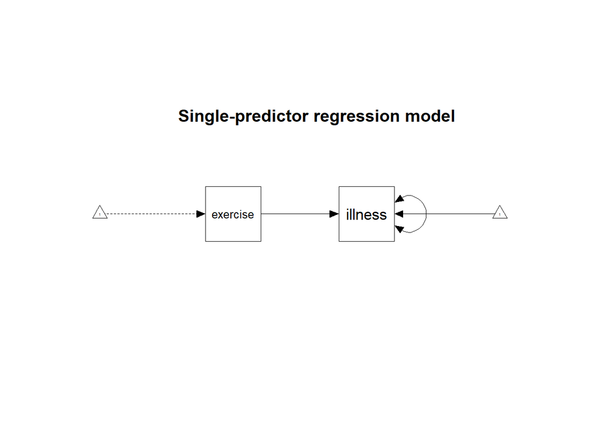

#### Especificação do modelo

- O objeto “model.1” define a fórmula do modelo

```r
model.1 <- "
illness ~ exercise" # illness em função de exercise
```

#### Estimação do modelo

- Estimamos este modelo no lavaan usando a função sem(), atribuindo o resultado ao objeto fit.1.
- Incluímos o argumento “meanstructure” para que o intercept da regressão seja estimado.

```r
fit.1 <- sem(model.1, data=DF_roth, meanstructure=T)
```

#### Extração dos resultados

- Por fim, usamos a função summary() para extrair os resultados da estimação do modelo especificado.

```r
summary(fit.1, standardized = TRUE, rsquare = TRUE)
```

```
## lavaan 0.6-6 ended normally after 13 iterations
##
##   Estimator                                         ML
##   Optimization method                           NLMINB
##   Number of free parameters                          3
##
##   Number of observations                           373
##
## Model Test User Model:
##
##   Test statistic                                 0.000
##   Degrees of freedom                                 0
##
## Parameter Estimates:
##
##   Standard errors                             Standard
##   Information                                 Expected
##   Information saturated (h1) model          Structured
##
## Regressions:
##                    Estimate  Std.Err  z-value  P(>|z|)   Std.lv  Std.all
##   illness ~
##     exercise         -0.075    0.048   -1.550    0.121   -0.075   -0.080
##
## Intercepts:
##                    Estimate  Std.Err  z-value  P(>|z|)   Std.lv  Std.all
##    .illness         719.774    3.782  190.309    0.000  719.774   11.536
##
## Variances:
##                    Estimate  Std.Err  z-value  P(>|z|)   Std.lv  Std.all
##    .illness        3868.368  283.262   13.657    0.000 3868.368    0.994
##
## R-Square:
##                    Estimate
##     illness           0.006
```

- Os resultados diferem ligeiramente dos resultados obtidos com a função lm() uma vez que agora estamos a utilizar um estimador diferente, o maximum likelihood (ML);
- O output apresenta informação acerca da amostra utilizada e do ajustamento do modelo, que neste caso é saturado (just identified).

## Modelo de regressão múltipla: efeito de exercise, hardy, fitness e stress em illness

- Expandimos agora o modelo anterior para incluir, para além de “exercise”, também “hardy”, “fitness” e “stress” como preditores de “illness.” É implicitamente definido pelo modelo que estes quatro preditores podem covariar.

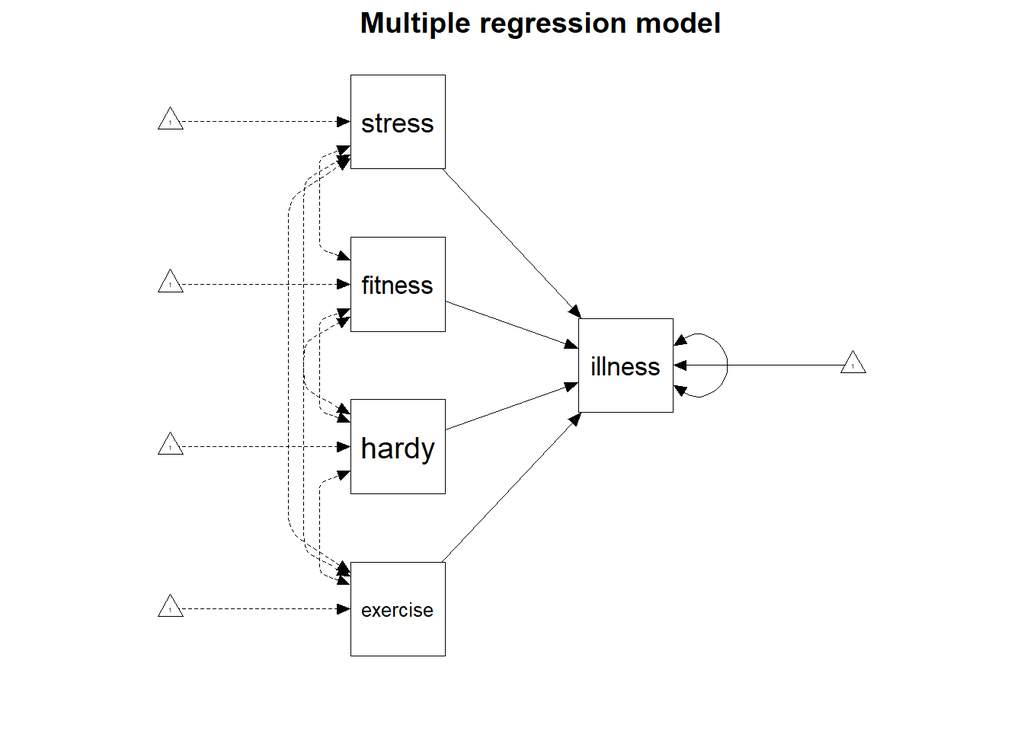

### Estimação OLS do modelo

```r
lm_fit.2 <- lm(formula = illness ~ exercise + hardy + fitness + stress, data = DF_roth)

summary(lm_fit.2)
```

```
##
## Call:
## lm(formula = illness ~ exercise + hardy + fitness + stress, data = DF_roth)
##
## Residuals:
##      Min       1Q   Median       3Q      Max
## -145.771  -40.522    0.884   36.327  163.622
##
## Coefficients:
##              Estimate Std. Error t value Pr(>|t|)
## (Intercept) 743.74194    6.19749 120.007  < 2e-16 ***
## exercise      0.03176    0.04816   0.659    0.510
## hardy        -0.12146    0.07981  -1.522    0.129
## fitness      -0.44177    0.08766  -5.040 7.33e-07 ***
## stress        0.27125    0.04545   5.967 5.67e-09 ***
## ---
## Signif. codes:  0 '***' 0.001 '**' 0.01 '*' 0.05 '.' 0.1 ' ' 1
##
## Residual standard error: 56.76 on 368 degrees of freedom
## Multiple R-squared:  0.1835, Adjusted R-squared:  0.1746
## F-statistic: 20.67 on 4 and 368 DF,  p-value: 2.208e-15
```

### Regressão múltipla no lavaan

```r
model.2 <- "
illness ~ exercise + hardy + fitness + stress"
fit.2 <- sem(model.2, data=DF_roth, meanstructure=TRUE)
```

- **illness = *β*1 + *β*2.exercise + *β*3.hardy + *β*4.fitness + *β*5.stress + *ϵ**
  - Os parâmetros *β*2, *β*3, *β*4 e *β*5 são interpretados respetivamente como os efeitos de *exercise*, *hardy*, *fitness* e *stress* sobre *illness*, mantendo constantes os restantes preditores. *β*1 (intercept) representa o valor esperado de illness quando todos os preditores assumem o valor de zero.

```r
summary(fit.2, standardized = TRUE, rsquare = TRUE)
```

```
## lavaan 0.6-6 ended normally after 17 iterations
##
##   Estimator                                         ML
##   Optimization method                           NLMINB
##   Number of free parameters                          6
##
##   Number of observations                           373
##
## Model Test User Model:
##
##   Test statistic                                 0.000
##   Degrees of freedom                                 0
##
## Parameter Estimates:
##
##   Standard errors                             Standard
##   Information                                 Expected
##   Information saturated (h1) model          Structured
##
## Regressions:
##                    Estimate  Std.Err  z-value  P(>|z|)   Std.lv  Std.all
##   illness ~
##     exercise          0.032    0.048    0.664    0.507    0.032    0.034
##     hardy            -0.121    0.079   -1.532    0.126   -0.121   -0.074
##     fitness          -0.442    0.087   -5.074    0.000   -0.442   -0.260
##     stress            0.271    0.045    6.008    0.000    0.271    0.291
##
## Intercepts:
##                    Estimate  Std.Err  z-value  P(>|z|)   Std.lv  Std.all
##    .illness         743.742    6.156  120.819    0.000  743.742   11.920
##
## Variances:
##                    Estimate  Std.Err  z-value  P(>|z|)   Std.lv  Std.all
##    .illness        3178.984  232.782   13.657    0.000 3178.984    0.817
##
## R-Square:
##                    Estimate
##     illness           0.183
```

- **Concluímos que os efeitos de *Exercise* (*p* = .507) e *hardy* (*p* = .126) deixam ser significativos, quando *fitness* e *stress* são também incluídos no modelo. No entanto, *fitness* e *stress* predizem significativamente *illness*.**
  - Por exemplo, o modelo estima que um ponto de aumento em *fitness* está associado a um decréscimo médio de quase meio ponto (*b* = -.44) na escala de *ilness*.
- Pela análise do R-Square (R^2) podemos ver que o modelo explica quase 20% da variância de *illnesse*, ficando um pouco mais de 80% da variância por explicar.

## Modelos de pistas (Mediação)

- Este modelo reproduz o modelo de mediação apresentado por Rex Kline em *Principles and Practice of SEM* (3ª ed.), figure 8.1.

#### Especificação e estimação do modelo

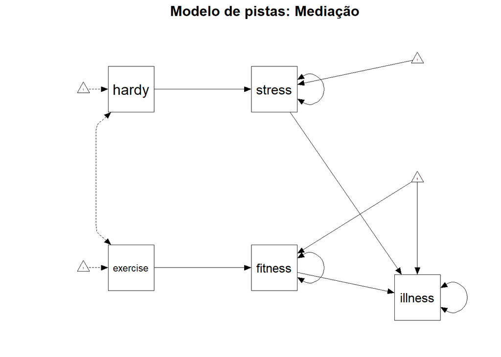

- No lavaan o modelo é especificado através da seguinte fórmula

```r
model.3 <- "
# regressões
fitness ~ exercise
stress ~ hardy
illness ~ fitness + stress
"

fit.3 <- sem(model.3, data=DF_roth, meanstructure=T)
```

#### Extração dos resultados

- Os resultados do modelo podem ser obtidos com recurso à função **summary()**

```r
summary(fit.3, fit.measures = TRUE, standardized = TRUE, rsquare = TRUE)
```

```
## lavaan 0.6-6 ended normally after 25 iterations
##
##   Estimator                                         ML
##   Optimization method                           NLMINB
##   Number of free parameters                         10
##
##   Number of observations                           373
##
## Model Test User Model:
##
##   Test statistic                                11.107
##   Degrees of freedom                                 5
##   P-value (Chi-square)                           0.049
##
## Model Test Baseline Model:
##
##   Test statistic                               165.608
##   Degrees of freedom                                 9
##   P-value                                        0.000
##
## User Model versus Baseline Model:
##
##   Comparative Fit Index (CFI)                    0.961
##   Tucker-Lewis Index (TLI)                       0.930
##
## Loglikelihood and Information Criteria:
##
##   Loglikelihood user model (H0)              -5964.539
##   Loglikelihood unrestricted model (H1)      -5958.985
##
##   Akaike (AIC)                               11949.077
##   Bayesian (BIC)                             11988.293
##   Sample-size adjusted Bayesian (BIC)        11956.566
##
## Root Mean Square Error of Approximation:
##
##   RMSEA                                          0.057
##   90 Percent confidence interval - lower         0.003
##   90 Percent confidence interval - upper         0.103
##   P-value RMSEA <= 0.05                          0.336
```

[output cut: 23 more lines]

```
##    .fitness          58.273    2.058   28.318    0.000   58.273    1.586
##    .stress            4.800    3.372    1.424    0.155    4.800    0.072
##    .illness         743.808    6.104  121.849    0.000  743.808   12.044
##
## Variances:
##                    Estimate  Std.Err  z-value  P(>|z|)   Std.lv  Std.all
##    .fitness        1145.181   83.856   13.657    0.000 1145.181    0.848
##    .stress         4240.134  310.485   13.657    0.000 4240.134    0.947
##    .illness        3203.954  234.610   13.657    0.000 3203.954    0.840
##
## R-Square:
##                    Estimate
##     fitness           0.152
##     stress            0.053
##     illness           0.160
```

#### Avaliar o ajustamento do modelo

- Tendo em conta que se trata de um modelo sobre-identificado (overidentified), é possível avaliar o seu ajustamento aos dados;
- Esta avaliação pode ser feita com recurso a vários indicadores, nomeadamente pela análise dos resíduos do modelo.

```r
residuals(fit.3, type = "raw")
```

```
## $type
## [1] "raw"
##
## $cov
##          fitnss   stress   illnss   exercs   hardy
## fitness     0.000
## stress   -326.286    0.000
## illness   -93.563  138.508   79.435
## exercise    0.000 -252.838   63.765    0.000
## hardy     113.943    0.000 -218.321    0.000    0.000
##
## $mean
##  fitness   stress  illness exercise    hardy
##        0        0        0        0        0
```

```r
residuals(fit.3, type = "cor")
```

```
## $type
## [1] "cor.bollen"
##
## $cov
##          fitnss stress illnss exercs hardy
## fitness   0.000
## stress   -0.133  0.000
## illness  -0.038  0.030  0.000
## exercise  0.000 -0.057  0.016  0.000
## hardy     0.082  0.000 -0.091  0.000  0.000
##
## $mean
##  fitness   stress  illness exercise    hardy
##        0        0        0        0        0
```

```r
resid(fit.3, type="normalized") # resíduo dividido pelo devios padrão estimado dos resíduos
```

```
## $type
## [1] "normalized"
##
## $cov
##          fitnss stress illnss exercs hardy
## fitness   0.000
## stress   -2.554  0.000
## illness  -0.759  0.608  0.279
## exercise  0.000 -1.131  0.302  0.000
## hardy     1.720  0.000 -1.811  0.000  0.000
##
## $mean
##  fitness   stress  illness exercise    hardy
##        0        0        0        0        0
```

- Os resíduos normalizados não devem estar fora do intervalo [-2; 2]. Valores claramente fora deste intervalo podem indicar presença de outliers ou a necessidade de re-especificar o modelo
- **Podemos ainda recorrer aos diferentes indicadores de ajustamento calculados pelo lavaan.**
  - A lista completa de indicadores de ajustamento disponíveis é a seguinte:

```r
fitMeasures(fit.3)
```

```
##                npar                fmin               chisq                  df
##              10.000               0.015              11.107               5.000
##              pvalue      baseline.chisq         baseline.df     baseline.pvalue
##               0.049             165.608               9.000               0.000
##                 cfi                 tli                nnfi                 rfi
##               0.961               0.930               0.930               0.879
##                 nfi                pnfi                 ifi                 rni
##               0.933               0.518               0.962               0.961
##                logl   unrestricted.logl                 aic                 bic
##           -5964.539           -5958.985           11949.077           11988.293
##              ntotal                bic2               rmsea      rmsea.ci.lower
##             373.000           11956.566               0.057               0.003
##      rmsea.ci.upper        rmsea.pvalue                 rmr          rmr_nomean
##               0.103               0.336             116.050             134.003
##                srmr        srmr_bentler srmr_bentler_nomean                crmr
##               0.044               0.044               0.051               0.059
##         crmr_nomean          srmr_mplus   srmr_mplus_nomean               cn_05
##               0.062               0.052               0.051             372.759
##               cn_01                 gfi                agfi                pgfi
##             507.612               1.000               0.999               0.250
##                 mfi                ecvi
##               0.992               0.083
```

- Em psicologia, alguns indicadores mais usados são:

```r
fitMeasures(fit.3, c("chisq", "df", "pvalue", "rmsea", "rmsea.ci.lower", "rmsea.ci.upper", "cfi", "tli",  "srmr"))
```

```
##          chisq             df         pvalue          rmsea rmsea.ci.lower
##         11.107          5.000          0.049          0.057          0.003
## rmsea.ci.upper            cfi            tli           srmr
##          0.103          0.961          0.930          0.044
```

Existem diferentes guidelines para interpretar os vários indicadores. Uma proposta pode ser encontrada [**aqui**](https://www.cscu.cornell.edu/news/Handouts/SEM_fit.pdf).

Uma discussão mais aprofundada acerca dos diferentes indicadores de ajustamento poderá ser lida neste [**link**](http://web.pdx.edu/~newsomj/semclass/ho_fit.pdf) .

#### Re-especificação do modelo

- Frequentemente, é necessário alterar ou re-especificar um modelo original. A re-especificação do modelo pode e deve ser feita tendo em conta a teoria orientadora. É também possível recorrer aos índices de modificação calculados pelo lavaan para perceber as consequências de eventuais alterações no ajustamento do modelo. Estes índices de modificação podem ser solicitados através do seguinte código:

```r
modindices(fit.3, sort.=TRUE, minimum.value=2) # o primeiro argumento é um objeto gerado pelo lavaan, o segundo (sort.) indica que pretendemos uma lista ordenada com base no índice de modificação e o terceiro (minimum.value) permite filtrar a lista com base no valor mínimo
```

```
##         lhs op     rhs    mi      epc  sepc.lv sepc.all sepc.nox
## 19  fitness  ~  stress 5.372   -0.061   -0.061   -0.111   -0.111
## 22   stress  ~ fitness 5.110   -0.207   -0.207   -0.114   -0.114
## 20  fitness  ~ illness 4.386   -0.125   -0.125   -0.211   -0.211
## 16  fitness ~~  stress 3.907 -225.512 -225.512   -0.102   -0.102
## 33    hardy  ~ illness 3.680   -0.065   -0.065   -0.106   -0.106
## 21  fitness  ~   hardy 2.939    0.079    0.079    0.082    0.002
## 26  illness  ~   hardy 2.466   -0.125   -0.125   -0.077   -0.002
## 31    hardy  ~ fitness 2.095    0.071    0.071    0.069    0.069
## 27 exercise  ~ fitness 2.095    4.137    4.137    2.290    2.290
```

- No output, a coluna **mi** expressa a melhoria do chi quadrado do modelo em resultado da inclusão do parâmetro no modelo, enquanto que a coluna **epc** “expected parameter change” expressa o valor esperado do parâmetro a modificar.
- De seguida fazemos a re-especificação do modelo e tentamos perceber em que medida isso resulta num melhor ajustamento. O modelo que propomos acrescenta os efeitos diretos de *exercise* e *hardy* sobre *illness*, bem como a covariação entre *fitness* e *stress*.

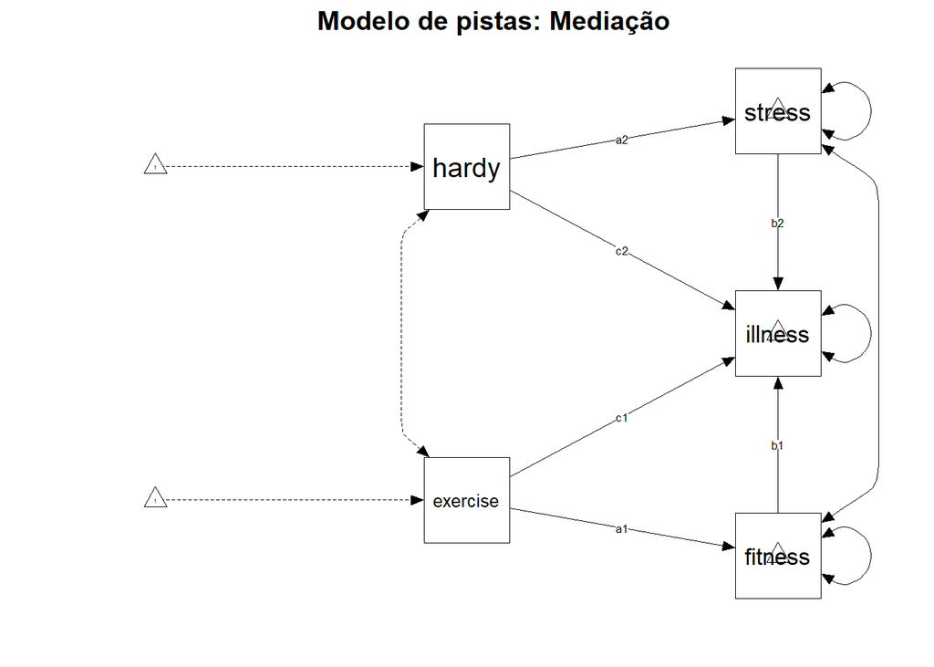

- Especificamos este modelo da seguinte forma:

```r
model.4 <- "
# regressões
fitness ~ a1*exercise
stress ~ a2*hardy
illness ~ b1*fitness + b2*stress + c1*exercise + c2*hardy

# covariações
fitness ~~ stress

ind1 := a1*b1
total1 := c1 + (a1*b1)

ind2 := a2*b2
total2 := c2 + (a2*b2)
"
```

```r
fit.4 <- sem(model.4, data=DF_roth, meanstructure=T, se = "bootstrap", bootstrap = 100)
summary(fit.4, fit.measures = TRUE, standardized = TRUE, rsquare = TRUE)
```

```
## lavaan 0.6-6 ended normally after 50 iterations
##
##   Estimator                                         ML
##   Optimization method                           NLMINB
##   Number of free parameters                         13
##
##   Number of observations                           373
##
## Model Test User Model:
##
##   Test statistic                                 4.217
##   Degrees of freedom                                 2
##   P-value (Chi-square)                           0.121
##
## Model Test Baseline Model:
##
##   Test statistic                               165.608
##   Degrees of freedom                                 9
##   P-value                                        0.000
##
## User Model versus Baseline Model:
##
##   Comparative Fit Index (CFI)                    0.986
##   Tucker-Lewis Index (TLI)                       0.936
##
## Loglikelihood and Information Criteria:
##
##   Loglikelihood user model (H0)              -5961.093
##   Loglikelihood unrestricted model (H1)      -5958.985
##
##   Akaike (AIC)                               11948.187
##   Bayesian (BIC)                             11999.167
##   Sample-size adjusted Bayesian (BIC)        11957.922
##
## Root Mean Square Error of Approximation:
##
##   RMSEA                                          0.055
##   90 Percent confidence interval - lower         0.000
##   90 Percent confidence interval - upper         0.128
##   P-value RMSEA <= 0.05                          0.356
```

[output cut: 37 more lines]

```
##    .stress         4240.491  291.571   14.544    0.000 4240.491    0.951
##    .illness        3178.984  209.350   15.185    0.000 3178.984    0.824
##
## R-Square:
##                    Estimate
##     fitness           0.148
##     stress            0.049
##     illness           0.176
##
## Defined Parameters:
##                    Estimate  Std.Err  z-value  P(>|z|)   Std.lv  Std.all
##     ind1             -0.094    0.022   -4.334    0.000   -0.094   -0.100
##     total1           -0.062    0.044   -1.401    0.161   -0.062   -0.067
##     ind2             -0.106    0.027   -3.861    0.000   -0.106   -0.065
##     total2           -0.227    0.067   -3.406    0.001   -0.227   -0.139
```

- Os intervalos de confiança para o modelo podem ser pedidos através da função **parameterestimates()**:

```r
parameterestimates(fit.4) # se necessário intervalos de confiança
```

```
##         lhs op        rhs  label      est      se       z pvalue ci.lower
## 1   fitness  ~   exercise     a1    0.213   0.030   7.028  0.000    0.147
## 2    stress  ~      hardy     a2   -0.390   0.086  -4.547  0.000   -0.566
## 3   illness  ~    fitness     b1   -0.442   0.083  -5.301  0.000   -0.592
## 4   illness  ~     stress     b2    0.271   0.036   7.448  0.000    0.203
## 5   illness  ~   exercise     c1    0.032   0.046   0.689  0.491   -0.066
## 6   illness  ~      hardy     c2   -0.121   0.070  -1.747  0.081   -0.263
## 7   fitness ~~     stress        -228.076 114.601  -1.990  0.047 -449.181
## 8   fitness ~~    fitness        1145.223  87.021  13.160  0.000  954.956
## 9    stress ~~     stress        4240.491 291.571  14.544  0.000 3692.299
## 10  illness ~~    illness        3178.984 209.350  15.185  0.000 2675.312
## 11 exercise ~~   exercise        4410.394   0.000      NA     NA 4410.394
## 12 exercise ~~      hardy         -75.607   0.000      NA     NA  -75.607
## 13    hardy ~~      hardy        1440.129   0.000      NA     NA 1440.129
## 14  fitness ~1                     58.398   2.029  28.785  0.000   54.178
```

[output cut: 31 more lines]

- Finalmente podemos comparar os dois modelos aninhados (modelo 3 e 4) recorrendo ao Teste da razão de verossimilhança (Likelihood Ratio Test - LRT). Este teste determina se os modelos apresentam diferenças significativas no seu ajustamento aos dados.

```r
anova(fit.3, fit.4)
```

```
## Chi-Squared Difference Test
##
##       Df   AIC   BIC  Chisq Chisq diff Df diff Pr(>Chisq)
## fit.4  2 11948 11999  4.217
## fit.3  5 11949 11988 11.107     6.8905       3    0.07547 .
## ---
## Signif. codes:  0 '***' 0.001 '**' 0.01 '*' 0.05 '.' 0.1 ' ' 1
```

```r
# OU
lavTestLRT(fit.3, fit.4)
```

```
## Chi-Squared Difference Test
##
##       Df   AIC   BIC  Chisq Chisq diff Df diff Pr(>Chisq)
## fit.4  2 11948 11999  4.217
## fit.3  5 11949 11988 11.107     6.8905       3    0.07547 .
## ---
## Signif. codes:  0 '***' 0.001 '**' 0.01 '*' 0.05 '.' 0.1 ' ' 1
```

- Uma vez que *p* > .05 não podemos rejeitar a hipótese nula de que não existem diferenças entre os ajustamentos dos modelos. Quer isto dizer que os dois modelos não apresentam diferenças significativas no seu ajustamento.
- Podemos comparar os restantes indicadores de ajustamento com recurso à função **compareFit()** do pacote semTools.

```r
library(semTools)
compareFit(fit.3, fit.4, nested = TRUE)
```

```
## ################### Nested Model Comparison #########################
## Chi-Squared Difference Test
##
##       Df   AIC   BIC  Chisq Chisq diff Df diff Pr(>Chisq)
## fit.4  2 11948 11999  4.217
## fit.3  5 11949 11988 11.107     6.8905       3    0.07547 .
## ---
## Signif. codes:  0 '***' 0.001 '**' 0.01 '*' 0.05 '.' 0.1 ' ' 1
##
## ####################### Model Fit Indices ###########################
##         chisq df pvalue   cfi   tli        aic        bic rmsea  srmr
## fit.4  4.217†  2   .121 .986† .936† 11948.187† 11999.167  .055† .025†
## fit.3 11.107   5   .049 .961  .930  11949.077  11988.293† .057  .044
##
## ################## Differences in Fit Indices #######################
##               df    cfi    tli  aic     bic rmsea  srmr
## fit.3 - fit.4  3 -0.025 -0.006 0.89 -10.874 0.003 0.019
```